# MacularDegeneration

```r
library(vroom)
library(nlme)
library(dplyr)
library(tidyr)
library(ggplot2)
library(corrplot)
library(multcomp)
library(emmeans)
```

```r
ARMD <- vroom('ARMD.txt', show_col_types = FALSE) |>
  mutate(Trt = as.factor(Trt)) |>
  mutate(Visit = as.numeric(factor(Time, levels = c(4,12,24,52)))) |>
  mutate(Difference = Vision - Baseline)
ARMD
```

```
# A tibble: 200 × 7
   Subject  Time Trt   Baseline Vision Visit Difference
     <dbl> <dbl> <fct>    <dbl>  <dbl> <dbl>      <dbl>
 1       1     4 0           41     42     1          1
 2       1    12 0           41     33     2         -8
 3       1    24 0           41     30     3        -11
 4       1    52 0           41     23     4        -18
 5       2     4 0           74     76     1          2
 6       2    12 0           74     65     2         -9
 7       2    24 0           74     50     3        -24
 8       2    52 0           74     46     4        -28
 9       3     4 0           40     42     1          2
10       3    12 0           40     40     2          0
# ℹ 190 more rows
```

## EDA

Violin Plot to visualize data

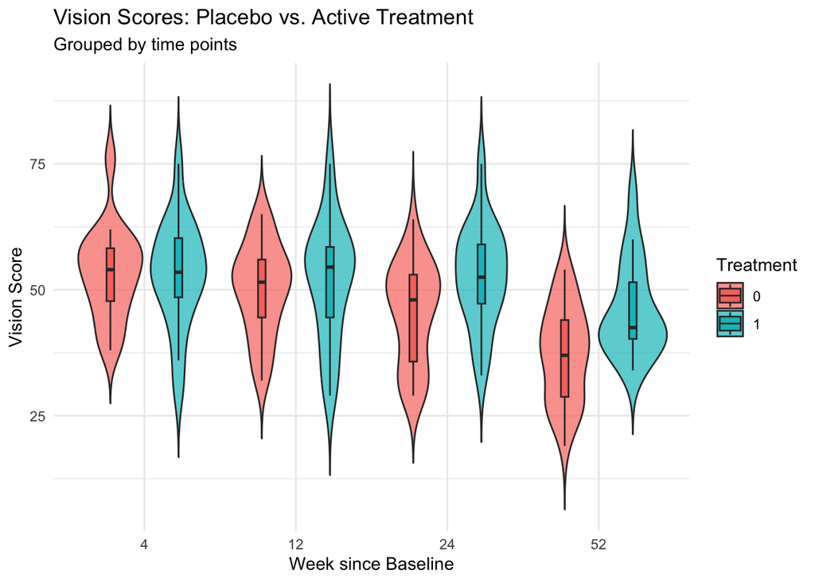

```r
ggplot(ARMD, aes(x = as.factor(Time), y = Vision, fill = Trt, group = interaction(Time, Trt))) +
  geom_violin(trim = FALSE, alpha = 0.7, position = position_dodge(0.9)) +
  geom_boxplot(width = 0.1, position = position_dodge(0.9), outlier.shape = NA) +
  theme_minimal() +
  labs(
    title = "Vision Scores: Placebo vs. Active Treatment",
    subtitle = "Grouped by time points",
    x = "Week since Baseline",
    y = "Vision Score",
    fill = "Treatment"
  )
```

Violin Plot to visualize differences data

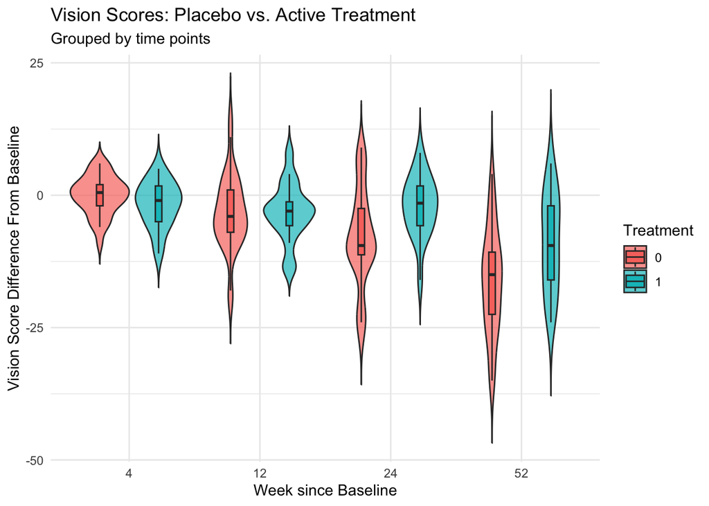

```r
ggplot(ARMD, aes(x = as.factor(Time), y = Difference, fill = Trt, group = interaction(Time, Trt))) +
  geom_violin(trim = FALSE, alpha = 0.7, position = position_dodge(0.9)) +
  geom_boxplot(width = 0.1, position = position_dodge(0.9), outlier.shape = NA) +
  theme_minimal() +
  labs(
    title = "Vision Scores: Placebo vs. Active Treatment",
    subtitle = "Grouped by time points",
    x = "Week since Baseline",
    y = "Vision Score Difference From Baseline",
    fill = "Treatment"
  )
```

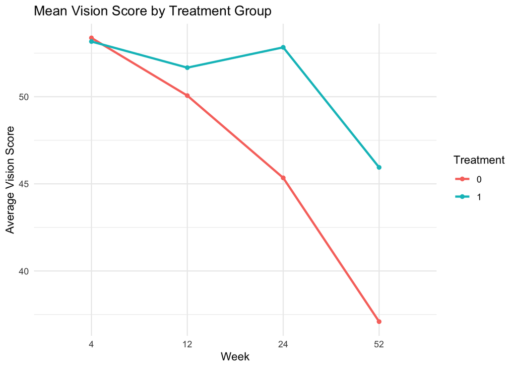

```r
armd_summary <- ARMD %>%
  mutate(Week = as.factor(Time)) |>
  group_by(Trt, Week) %>%
  summarise(mean_vis = mean(Vision, na.rm = TRUE), .groups = "drop")

ggplot(data=armd_summary, aes(x = Week, y = mean_vis, color = Trt, group = Trt)) +
  geom_line(linewidth = 1) +
  geom_point() +
  labs(y = "Average Vision Score",
       title = "Mean Vision Score by Treatment Group",
       color = "Treatment") +
  theme_minimal()
```

```r
ARMD_long <- ARMD |>
  pivot_wider(id_cols = c(Subject, Trt, Baseline),
              names_from = Time, values_from = Vision, names_prefix = "week_")

cor_matrix <- ARMD_long |>
  dplyr::select(starts_with("week_")) |>
  cor(use = "pairwise.complete.obs")

print(cor_matrix)
```

```
           week_4   week_12   week_24   week_52
week_4  1.0000000 0.8437114 0.6337933 0.5103195
week_12 0.8437114 1.0000000 0.7576143 0.5808148
week_24 0.6337933 0.7576143 1.0000000 0.6861501
week_52 0.5103195 0.5808148 0.6861501 1.0000000
```

```r
# block model
block_model <- gls(
  Vision ~ Baseline + Time + Trt + Time:Trt,
  data = ARMD,
  correlation = corSymm(form = ~ Visit | Subject)
)

block_model$modelStruct$corStruct
```

```
Correlation structure of class corSymm representing
 Correlation:
  1     2     3
2 0.674
3 0.164 0.464
4 0.106 0.260 0.385
```

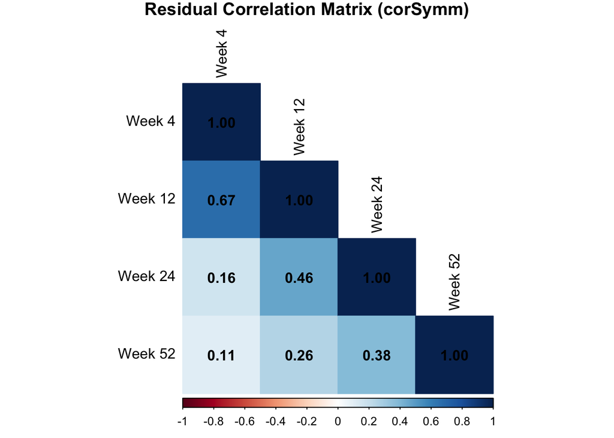

```r
library(corrplot)

# 1. Use the specialized corMatrix function to expand the structure
# We take the first element [[1]] because corMatrix returns a list of matrices per subject
res_cor_matrix <- nlme::corMatrix(block_model$modelStruct$corStruct)[[1]]

# 2. Now it has two dimensions, so we can set the names
colnames(res_cor_matrix) <- c("Week 4", "Week 12", "Week 24", "Week 52")
rownames(res_cor_matrix) <- c("Week 4", "Week 12", "Week 24", "Week 52")

# 3. Plot it
corrplot(res_cor_matrix,
         method = "color",
         addCoef.col = "black",
         type = "lower",
         tl.col = "black",
         title = "Residual Correlation Matrix (corSymm)",
         mar = c(0,0,1,0))
```

# EDA

Linearity

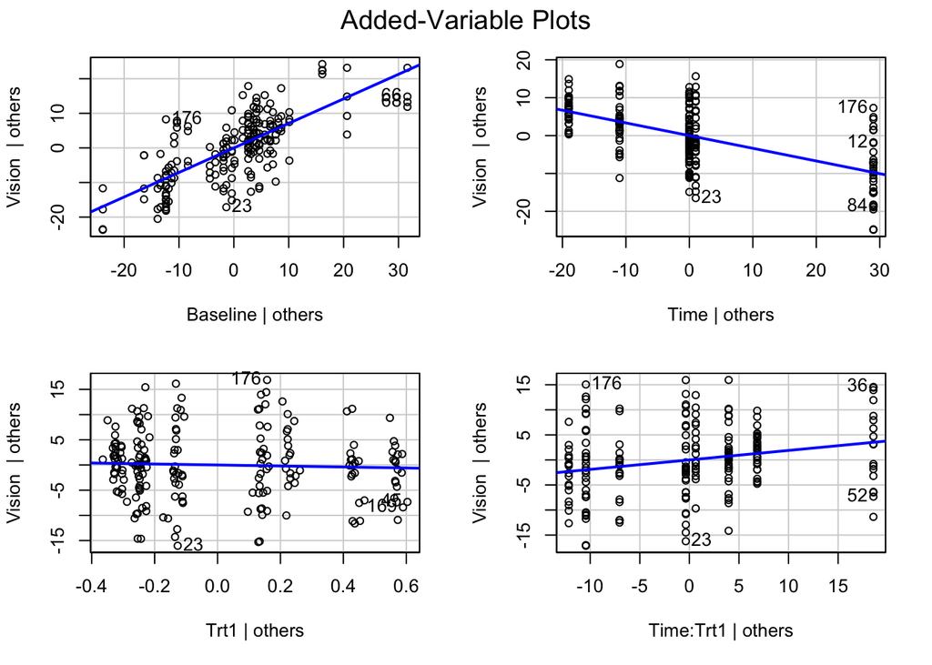

```r
# av plots only work for lm, so do for lm and it is same as block
lm_model <- lm(Vision ~ Baseline + Time + Trt + Time:Trt,
               data = ARMD)

# av plots
car::avPlots(lm_model, terms = ~., ask = FALSE)
```

Independence

```r
decorr_resid = residuals(block_model, type = "normalized")

ARMD_fr <- ARMD |>
  mutate(fitted = fitted(block_model), # or fitted = predict(block_model)
         decorr_resid = decorr_resid)

# “Wide format” correlation of residuals
res_wide <- ARMD_fr |>
  dplyr::select(Subject, Time, decorr_resid) |>
  pivot_wider(names_from = Time, values_from = decorr_resid, names_prefix = "res_") |>
  dplyr::select(-Subject)

# correlation matrix
cor(res_wide, use = "pairwise.complete.obs")
```

```
            res_4     res_12     res_24     res_52
res_4  1.00000000 0.07503946 0.01603995 0.05999285
res_12 0.07503946 1.00000000 0.07083147 0.07595854
res_24 0.01603995 0.07083147 1.00000000 0.08105749
res_52 0.05999285 0.07595854 0.08105749 1.00000000
```

Normality

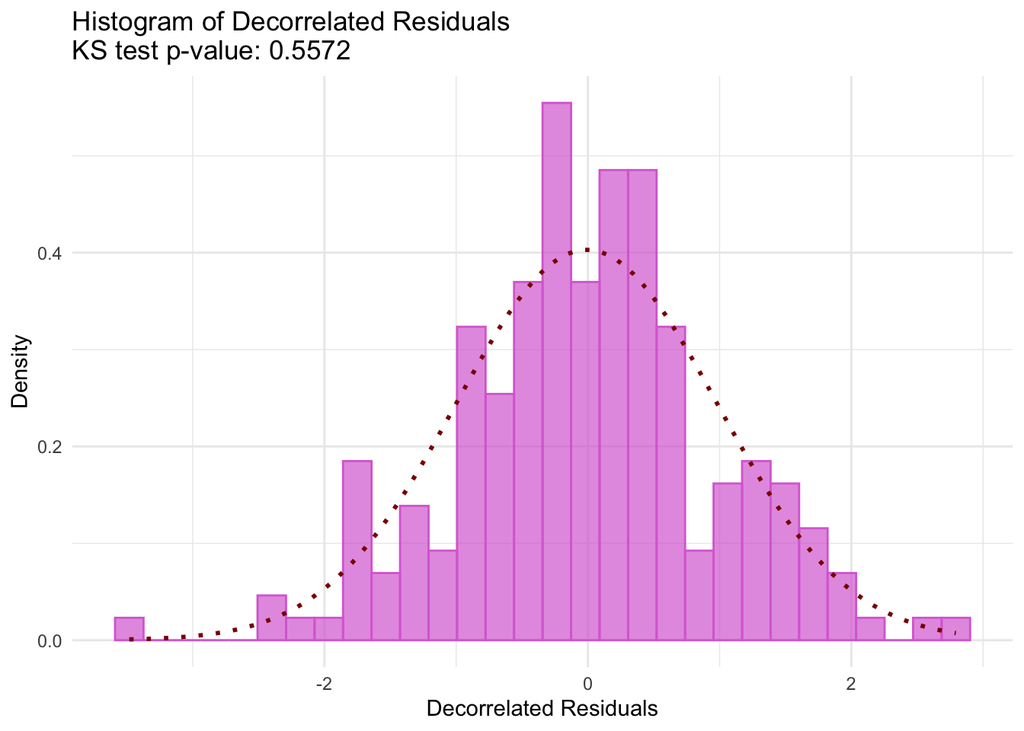

```r
# Standardized AND decorrelated residuals
ks <- ks.test(decorr_resid, "pnorm", mean=0, sd=1)
pval <- formatC(ks$p.value, digits = 4)

df <- data.frame(resids = decorr_resid)

ggplot(df, aes(x = resids)) +
  geom_histogram(aes(y = after_stat(density)), bins = 30, fill = "orchid",
                 alpha = 0.7, color = "orchid") +
  stat_function(fun = dnorm, args = list(mean = mean(decorr_resid),
                                         sd = sd(decorr_resid)),
                linewidth = 1, color = "darkred", linetype = "dotted") +
  labs(title = paste0("Histogram of Decorrelated Residuals",
                      "\nKS test p-value: ", pval),
       x = "Decorrelated Residuals",
       y = "Density") +
  theme_minimal()
```

Equal Variance

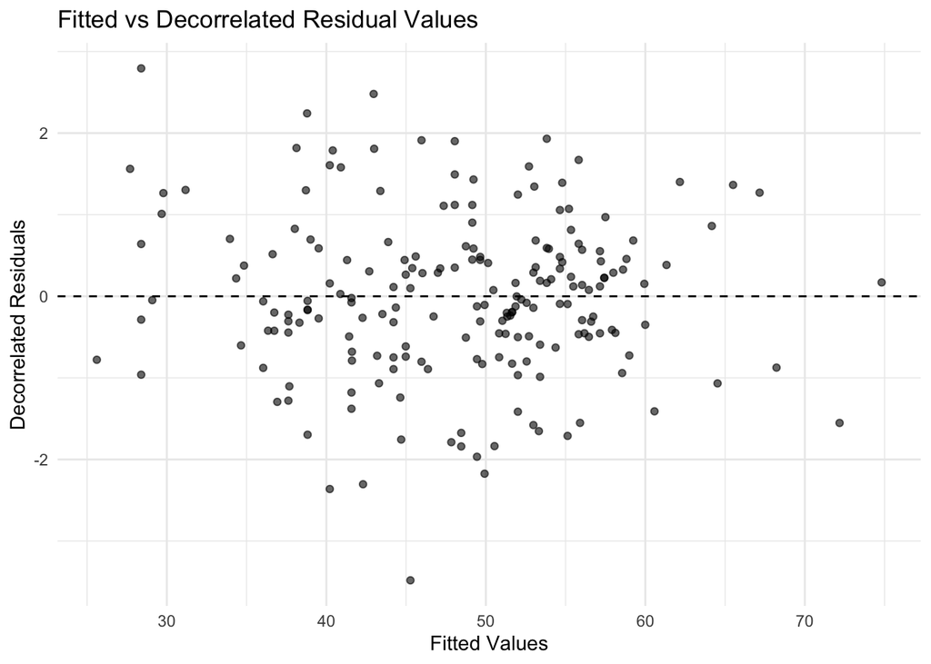

```r
fitted_vals <- fitted(block_model, what = "mu")

# plot: residuals vs fitted
ggplot(data.frame(fitted = fitted_vals, resid = decorr_resid),
       aes(x = fitted, y = resid)) +
  geom_point(alpha = 0.6) +
  geom_hline(yintercept = 0, linetype = "dashed") +
  labs(x = "Fitted Values",
       y = "Decorrelated Residuals",
       title = "Fitted vs Decorrelated Residual Values") +
  theme_minimal()
```

Psuedo $R^2$

```r
true_y <- ARMD$Vision
R2 <- cor(true_y, fitted_vals)^2
R2
```

```
[1] 0.6366455
```

64% of the variability in the data can be explained by our model

```r
confint(block_model)["Trt1", ]
```

```
    2.5 %    97.5 %
-4.104387  3.648861
```

```r
block_noint <- gls(
  Vision ~ Baseline + Time + Trt,
  data = ARMD,
  correlation = corSymm(form = ~ Visit | Subject)
)

anova(block_noint, block_model)
```

```
            Model df      AIC      BIC    logLik   Test  L.Ratio p-value
block_noint     1 11 1319.978 1356.037 -648.9891
block_model     2 12 1318.223 1357.499 -647.1113 1 vs 2 3.755503  0.0526
```

The p-val is close enough to being small that we should definitely keep our interaction model

```r
block_2 <- gls(
  Difference ~ Time + Trt + Time:Trt,
  data = ARMD,
  correlation = corSymm(form = ~ Visit | Subject)
)

R2
```

```
[1] 0.6366455
```

```r
cor(ARMD$Difference, fitted(block_2, what = "mu"))^2
```

```
[1] 0.3455903
```

We looked at Difference as the response variable and it was not good.

```r
# 1. Get predicted means specifically at your measurement weeks
plot_data <- emmeans(block_model, ~ Trt | Time,
                     at = list(Time = c(4, 12, 24, 52))) |>
             as.data.frame()
```

```
Analytical Satterthwaite method not available; using appx-satterthwaite
```

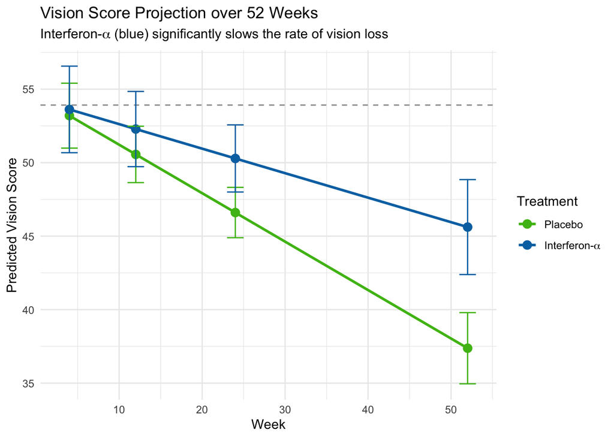

```r
# 2. Convert Time back to numeric for proper spacing on the x-axis
plot_data$Time <- as.numeric(as.character(plot_data$Time))

# 3. Create the plot
ggplot(plot_data, aes(x = Time, y = emmean, color = Trt, group = Trt)) +
  # Reference line for starting baseline
  geom_hline(yintercept = mean(ARMD$Baseline, na.rm=TRUE),
             linetype = "dashed", color = "gray60") +
  # The actual data
  geom_line(linewidth = 1) +
  geom_point(size = 3) +
  geom_errorbar(aes(ymin = lower.CL, ymax = upper.CL), width = 2) +
  # Colors and labels
  scale_color_manual(values = c("0" = "#4CBB17", "1" = "#0072B2"),
                     labels = c("Placebo", expression(paste("Interferon-",alpha)))) +
  theme_minimal() +
  labs(
    title = "Vision Score Projection over 52 Weeks",
    subtitle = expression(paste("Interferon-",alpha, " (blue) significantly slows the rate of vision loss")),
    x = "Week",
    y = "Predicted Vision Score",
    color = "Treatment"
  )
```

```r
# adj_means <- emmeans::emmeans(block_model, ~ Trt | Time)
# confint(adj_means)
hyp_1 <- glht(block_model, linfct = c("Trt1 = 0"))
summary(hyp_1)
```

```
     Simultaneous Tests for General Linear Hypotheses

Fit: gls(model = Vision ~ Baseline + Time + Trt + Time:Trt, data = ARMD,
    correlation = corSymm(form = ~Visit | Subject))

Linear Hypotheses:
          Estimate Std. Error z value Pr(>|z|)
Trt1 == 0  -0.2278     1.9779  -0.115    0.908
(Adjusted p values reported -- single-step method)
```

With a p-val of 0.908, we fail to reject the Null Hypothesis that “There is zero difference between the Active Treatment (Trt1) and the Placebo (Trt0) at the start of the study.” Basically at week 4, they are still starting at the same place.

```r
interaction_test <- glht(block_model, linfct = c("Time:Trt1 = 0"))
summary(interaction_test)
```

```
     Simultaneous Tests for General Linear Hypotheses

Fit: gls(model = Vision ~ Baseline + Time + Trt + Time:Trt, data = ARMD,
    correlation = corSymm(form = ~Visit | Subject))

Linear Hypotheses:
               Estimate Std. Error z value Pr(>|z|)
Time:Trt1 == 0  0.16286    0.05489   2.967  0.00301 **
---
Signif. codes:  0 '***' 0.001 '**' 0.01 '*' 0.05 '.' 0.1 ' ' 1
(Adjusted p values reported -- single-step method)
```

This is looking at the rate of change (the slope) across all weeks (4, 12, 24, 52). It asks: “Is the vision of the Treatment group dropping faster or slower than the Placebo group as the weeks go by?” We know by the estimate of 0.16286 that the treatment group is losing vision slower than the placebo group.

```r
# This tests the difference between Trt0 and Trt1 specifically at Week 52
pairs(emmeans::emmeans(block_model, ~ Trt | Time, at = list(Time = 52)))
```

```
Analytical Satterthwaite method not available; using appx-satterthwaite
```

```
Time = 52:
 contrast    estimate   SE  df t.ratio p.value
 Trt0 - Trt1    -8.24 2.04 126  -4.038 <0.0001

Degrees-of-freedom method: appx-satterthwaite
```

The Estimate (-8.24): This is the “Gap” between the two groups at one year. On average, the Placebo group (Trt0) scored 8.24 points lower in Vision than the Active group (Trt1). Since vision scores drop as the disease progresses, a negative “Trt0 - Trt1” means the treatment group kept significantly more of their sight.

The t.ratio (-4.038): This is a measure of how many “standard errors” the difference is away from zero. Anything beyond $\pm 2$ is usually noteworthy; a -4.038 is a very strong statistical signal.

The p-value (<0.0001): This is statistically significant.

```r
# We want to test if (Trt1 + 52*Time:Trt1) is different from 0
week52_test <- glht(block_model, linfct = c("Trt1 + 52*Time:Trt1 = 0"))
summary(week52_test)
```

```
     Simultaneous Tests for General Linear Hypotheses

Fit: gls(model = Vision ~ Baseline + Time + Trt + Time:Trt, data = ARMD,
    correlation = corSymm(form = ~Visit | Subject))

Linear Hypotheses:
                           Estimate Std. Error z value Pr(>|z|)
Trt1 + 52 * Time:Trt1 == 0    8.241      2.041   4.038 5.38e-05 ***
---
Signif. codes:  0 '***' 0.001 '**' 0.01 '*' 0.05 '.' 0.1 ' ' 1
(Adjusted p values reported -- single-step method)
```

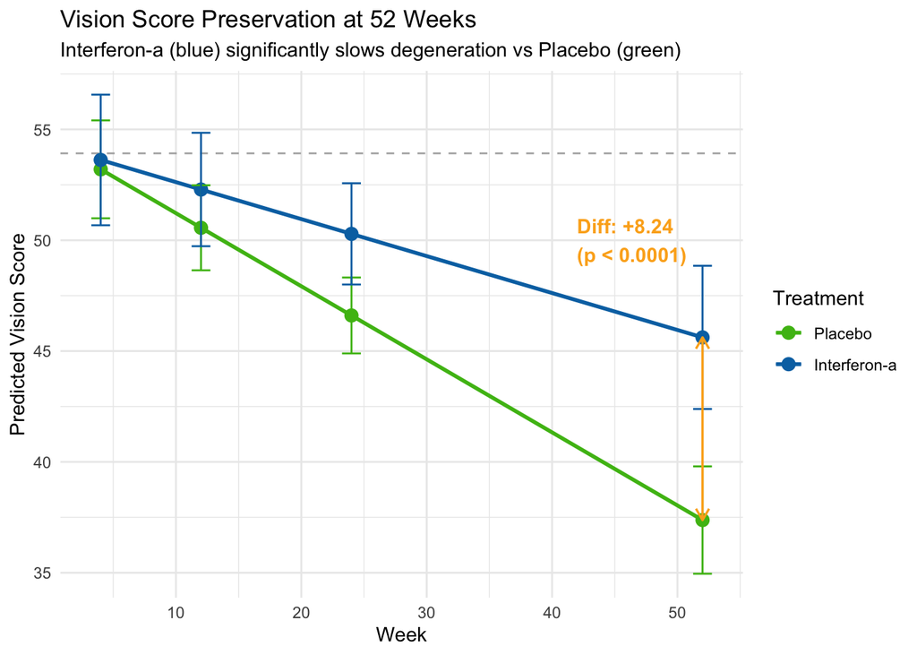

```r
ggplot(plot_data, aes(x = Time, y = emmean, color = Trt, group = Trt)) +
  # Baseline reference line
  geom_hline(yintercept = mean(ARMD$Baseline, na.rm=TRUE),
             linetype = "dashed", color = "gray70") +

  # Main data lines and points
  geom_line(linewidth = 1) +
  geom_point(size = 3) +
  geom_errorbar(aes(ymin = lower.CL, ymax = upper.CL), width = 1.5) +

  # ADD THE GAP ANNOTATION AT WEEK 52
  # Vertical line segment between the two groups at Week 52
  annotate("segment", x = 52, xend = 52,
           y = plot_data$emmean[plot_data$Time==52 & plot_data$Trt==0],
           yend = plot_data$emmean[plot_data$Time==52 & plot_data$Trt==1],
           colour = "#FCAE1E", linewidth = 0.6, linetype = "solid",
           arrow = arrow(ends = "both", length = unit(0.1, "inches"))) +

  # Text label for the 8.24 point difference
  annotate("text", x = 42, y = 50, label = "Diff: +8.24\n(p < 0.0001)",
           hjust = 0, fontface = "bold", color = "#FCAE1E") +

  # Styling
  scale_color_manual(values = c("0" = "#4CBB17", "1" = "#0072B2"),
                     labels = c("Placebo", "Interferon-a")) +
  theme_minimal() +
  # expand_limits(x = 60) + # Give room for the text on the right
  labs(
    title = "Vision Score Preservation at 52 Weeks",
    subtitle = "Interferon-a (blue) significantly slows degeneration vs Placebo (green)",
    x = "Week",
    y = "Predicted Vision Score",
    color = "Treatment"
  )
```